# Introduction to Python Project : FoodHub Data Analysis

### **Problem Statement**

##### **Context**

The number of restaurants in New York is increasing day by day. Lots of students and busy professionals  
rely on those restaurants due to their hectic lifestyles. Online food delivery service is a great option for  
them. It provides them with good food from their favorite restaurants.

A food aggregator company FoodHub offers access to multiple restaurants through a single smartphone app.  
The app allows restaurants to receive a direct online order from a customer. The app assigns a delivery  
person from the company to pick up the order after it is confirmed by the restaurant. The delivery person  
then uses the map to reach the restaurant and waits for the food package.

Once the food package is handed over to the delivery person, he/she confirms the pick-up in the app and  
travels to the customer's location to deliver the food.  
The delivery person confirms the drop-off in the app after delivering the food  
package to the customer. The customer can rate the order in the app.  
The food aggregator earns money by collecting a fixed margin on the delivery order from the restaurants.

##### **Objective**

The food aggregator company has stored the data of the different orders made by the registered  
customers in their online portal. They want to analyze the data to get a fair idea about the demand of  
different restaurants which will help them in enhancing their customer experience.

Suppose you are hired as a Data Scientist in this company and the Data Science team has  
shared some of the key questions that need to be answered. Perform the data analysis to find  
answers to these questions that will help the company improve its business.

### **Data Dictionary**

The data includes various information related to a food order. A detailed data dictionary is provided below.

- **order_id**: Unique ID of the order
- **customer_id**: ID of the customer who ordered the food
- **restaurant_name**: Name of the restaurant
- **cuisine_type**: Cuisine ordered by the customer
- **cost_of_the_order**: Cost of the order
- **day_of_the_week**: Indicates whether the order is placed on a weekday or weekend (The weekday is  
  from Monday to Friday and the weekend is Saturday and Sunday)
- **rating**: Rating given by the customer out of 5
- **food_preparation_time**: Time (in minutes) taken by the restaurant to prepare the food. This is  
  calculated by taking the difference between the timestamps of the  
  restaurant's order confirmation and the delivery person's pick-up confirmation.
- **delivery_time**: Time (in minutes) taken by the delivery person to deliver the food package. This is  
  calculated by taking the difference between the timestamps of the delivery  
  person's pick-up confirmation and drop-off information

### Let us start by importing the required libraries

```python
import warnings
import pandas as pd
import numpy as np
import matplotlib.pyplot as plt
import seaborn as sns

%matplotlib inline
warnings.filterwarnings("ignore", category=FutureWarning)
```

### Understanding the structure of the data

```python
# uncomment and run the following lines for Google Colab
# from google.colab import drive
# drive.mount('/content/drive')
```

```python
# Reading the dataset from a CSV file
data = pd.read_csv("foodhub_order.csv")
```

```python
# Keeping a copy of the original data
data_copy = data.copy()
```

```python
# Display the first 5 rows of the dataset
data.head(5)
```

|  | order_id | customer_id | restaurant_name | cuisine_type | cost_of_the_order | day_of_the_week | rating | food_preparation_time | delivery_time |
| --- | --- | --- | --- | --- | --- | --- | --- | --- | --- |
| 0 | 1477147 | 337525 | Hangawi | Korean | 30.75 | Weekend | Not given | 25 | 20 |
| 1 | 1477685 | 358141 | Blue Ribbon Sushi Izakaya | Japanese | 12.08 | Weekend | Not given | 25 | 23 |
| 2 | 1477070 | 66393 | Cafe Habana | Mexican | 12.23 | Weekday | 5 | 23 | 28 |
| 3 | 1477334 | 106968 | Blue Ribbon Fried Chicken | American | 29.20 | Weekend | 3 | 25 | 15 |
| 4 | 1478249 | 76942 | Dirty Bird to Go | American | 11.59 | Weekday | 4 | 25 | 24 |

**Observations**

- The restaurant_name column contains the name of the restaurants.
- The cost_of_the_order column indicates the total bill amount for the order.
- The day_of_the_week column indicates whether the order was placed on a weekend or weekday.
- The rating column indicates the rating provided by user after the order for the restaurant. Not all orders have a rating provided by the customer.
- The food_preparation_time column indicates the time it took to prepare the order.
- The delivery_time column indicates the time it took to deliver the order.

### **Question 1:** How many rows and columns are present in the data? [0.5 mark]

```python
# Write your code here
rows, cols = data.shape
print(f"Number of rows = {rows}\nNumber of columns = {cols}")
```

```
Number of rows = 1898
Number of columns = 9
```

**Observations**

- There are 1898 rows with 9 columns.
- This also means that we have 1898 datapoints across 9 different features.

### **Question 2:** What are the datatypes of the different columns in the dataset? (The info() function can be used) [0.5 mark]

```python
# Write your code here
data.info()
```

```
<class 'pandas.core.frame.DataFrame'>
RangeIndex: 1898 entries, 0 to 1897
Data columns (total 9 columns):
 #   Column                 Non-Null Count  Dtype
---  ------                 --------------  -----
 0   order_id               1898 non-null   int64
 1   customer_id            1898 non-null   int64
 2   restaurant_name        1898 non-null   object
 3   cuisine_type           1898 non-null   object
 4   cost_of_the_order      1898 non-null   float64
 5   day_of_the_week        1898 non-null   object
 6   rating                 1898 non-null   object
 7   food_preparation_time  1898 non-null   int64
 8   delivery_time          1898 non-null   int64
dtypes: float64(1), int64(4), object(4)
memory usage: 133.6+ KB
```

**Observations**

- Data is of either int64, float64 or object datatype.
- Order id, Customer id, Food preparation time and Delivery time are integer types.
- Cost of the order is float type.
- Restaurant name, Cuisine type, Day of the week are object type.
- Rating is object datatype but it should be a numerical datatype.

### **Question 3:** Are there any missing values in the data? If yes, treat them using an appropriate method. [1 mark]

```python
# Write your code here
data.isna().sum()
```

```
order_id                 0
customer_id              0
restaurant_name          0
cuisine_type             0
cost_of_the_order        0
day_of_the_week          0
rating                   0
food_preparation_time    0
delivery_time            0
dtype: int64
```

```python
# As such there are no missing values in the dataset
# But we can check for values in the "rating" column
# It has an object type instead of a numeric type
# which could mean some invalid entries
data["rating"].unique().tolist()
```

```
['Not given', '5', '3', '4']
```

```python
# Since the rating column has "Not given" as a value
# we can replace it with NaN and convert the column to float
# Ideally it should be integer but nan is a float
data["rating"] = data["rating"].replace("Not given", np.nan).astype("float64")
```

```python
# Sanity check to see if the conversion worked
data["rating"].unique().tolist()
```

```
[nan, 5.0, 3.0, 4.0]
```

**Observations**

- Ratings column has entries which indirectly indicate missing data.
- Ratings marked as 'Not given' have been converted to NaN value to convert the ratings to numeric datatype.
- Valid ratings from the data are either 3, 4 or 5.
- For purpose of eda, we will not replace NaN values with imputation techniques.

### **Question 4:** Check the statistical summary of the data. What is the minimum, average, and maximum time it takes for food to be prepared once an order is placed? [2 marks]

```python
#order_id and customer_id don't add much value to the analysis.
#They are just unique integers representing an order and customer possibly autogenerated.
#We can drop these two columns to have a clean dataframe of relevant columns.

data.drop(columns=['order_id', 'customer_id'], inplace=True)
```

```python
# Columns in the dataset after dropping the irrelevant ones
data.columns.tolist()
```

```
['restaurant_name',
 'cuisine_type',
 'cost_of_the_order',
 'day_of_the_week',
 'rating',
 'food_preparation_time',
 'delivery_time']
```

```python
# Statistical summary of the dataset
data.describe()
```

|  | cost_of_the_order | rating | food_preparation_time | delivery_time |
| --- | --- | --- | --- | --- |
| count | 1898.000000 | 1162.000000 | 1898.000000 | 1898.000000 |
| mean | 16.498851 | 4.344234 | 27.371970 | 24.161749 |
| std | 7.483812 | 0.741478 | 4.632481 | 4.972637 |
| min | 4.470000 | 3.000000 | 20.000000 | 15.000000 |
| 25% | 12.080000 | 4.000000 | 23.000000 | 20.000000 |
| 50% | 14.140000 | 5.000000 | 27.000000 | 25.000000 |
| 75% | 22.297500 | 5.000000 | 31.000000 | 28.000000 |
| max | 35.410000 | 5.000000 | 35.000000 | 33.000000 |

**Observations**  
**Time taken for food preparation once order is placed**

- minimum time taken = **20 minutes**
- average time taken = **27.37 minutes**
- maximum time taken = **35 minutes**

### **Question 5:** How many orders are not rated? [1 mark]

```python
# Checking NaN values in the rating column
# Since we replaced "Not given" with NaN, we can check for NaN values
data["rating"].isna().sum()
```

```
np.int64(736)
```

```python
# Percentage of NaN values in the rating column
data["rating"].isna().sum() / data.shape[0] * 100
```

```
np.float64(38.77766069546891)
```

**Observations**

- **736 orders** have not been given any rating.
- **38.77%** of whole data has no rating.

### Exploratory Data Analysis (EDA)

### **Question 6:** Explore all the variables and provide observations on their distributions. (Generally, histograms, boxplots, countplots, etc. are used for univariate exploration.) [9 marks]

```python
# Fetching the columns with numeric and categorical data
data_num = data.select_dtypes(include=["number"])
data_cat = data.select_dtypes(include=["object"])

# Rating will be treated as categorical variable for EDA
data_cat = data_cat.join(data_num["rating"])
data_num = data_num.drop(columns=["rating"])
```

```python
# Numeric columns in the dataset
print("Columns with numerical data are: ", data_num.columns.tolist())
```

```
Columns with numerical data are:  ['cost_of_the_order', 'food_preparation_time', 'delivery_time']
```

```python
# Categorical columns in the dataset
print("Columns with categorical data are: ", data_cat.columns.tolist())
```

```
Columns with categorical data are:  ['restaurant_name', 'cuisine_type', 'day_of_the_week', 'rating']
```

**Analyzing numerical columns**

- cost_of_the_order
- rating (Even though it is numeric, but we will treat this as categorical since ratings have ordinal nature)
- food_preparation_timecan on
- delivery_time

```python
# Numerical variables
data_num.describe()
```

|  | cost_of_the_order | food_preparation_time | delivery_time |
| --- | --- | --- | --- |
| count | 1898.000000 | 1898.000000 | 1898.000000 |
| mean | 16.498851 | 27.371970 | 24.161749 |
| std | 7.483812 | 4.632481 | 4.972637 |
| min | 4.470000 | 20.000000 | 15.000000 |
| 25% | 12.080000 | 23.000000 | 20.000000 |
| 50% | 14.140000 | 27.000000 | 25.000000 |
| 75% | 22.297500 | 31.000000 | 28.000000 |
| max | 35.410000 | 35.000000 | 33.000000 |

**Observations**

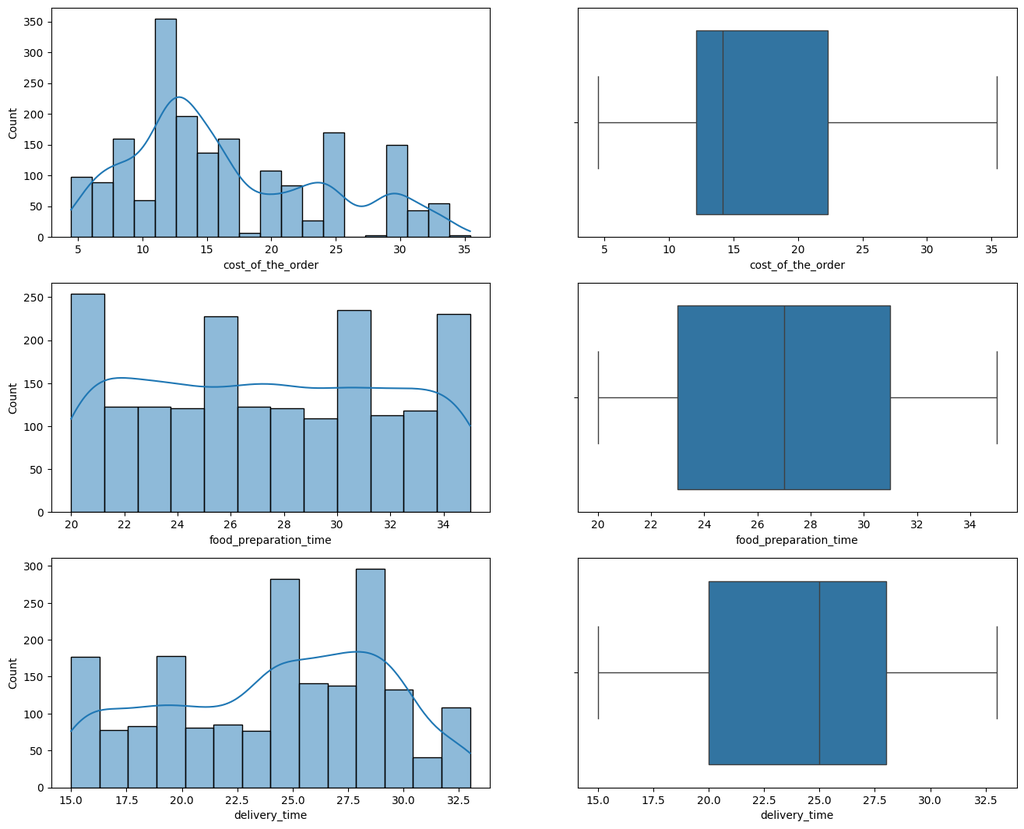

```python
fig, axes = plt.subplots(nrows=3, ncols=2)
fig.set_size_inches(16, 13)

sns.histplot(data['cost_of_the_order'], kde=True, ax=axes[0][0])
sns.boxplot(x='cost_of_the_order', data=data, ax=axes[0][1])

sns.histplot(data['food_preparation_time'], kde=True, ax=axes[1][0])
sns.boxplot(x='food_preparation_time', data=data, ax=axes[1][1])

sns.histplot(data['delivery_time'], kde=True, ax=axes[2][0])
sns.boxplot(x='delivery_time', data=data, ax=axes[2][1])


plt.show()
```

**Observations from plots:**

**cost_of_the_order**

- Distribution for cost of orders is right skewed
- Most of the orders are of low cost but there are few high cost orders
- There is a wide spread with some orders being significantly costlier than the others
- Median is positioned closer to lower quartile confirming right skewness observed in histogram
- IQR indicates moderate variability in order costs
- No outliers are present as per iqr estimate on the box plot

**food_preparation_time**

- Food preparation times seem uniformly spread across the observed range
- Mean and Median are nearly identical suggesting a symmetrical distribution
- Spread seems consistent with no significant clustering of values.
- Median is centrally located within IQR, suggesting uniformity of data.
- No outliers are present as per iqr estimate on the box plot
- Consistency of food preparation times indicate standardized kitchen operations and effecient workflow.

**delivery_time**

- Delivery times seem left skewed as per distribution indicating few instances if significantly shorter delivery times
- Majority of delivery times are concentrated on the right side representing longer delivery times
- Median line is closer to upper quartile indicating longer delivery times
- As such no outliers are present as per IQR estimation.

**Analyzing categorical columns**

- rating
- restaurant_name
- cuisine_type
- day_of_the_week

**Restaurant name**

```python
data['restaurant_name'].value_counts()[:5].sum() / data.shape[0] * 100
```

```
np.float64(33.40358271865121)
```

```python
len(data['restaurant_name'].unique().tolist())
```

```
178
```

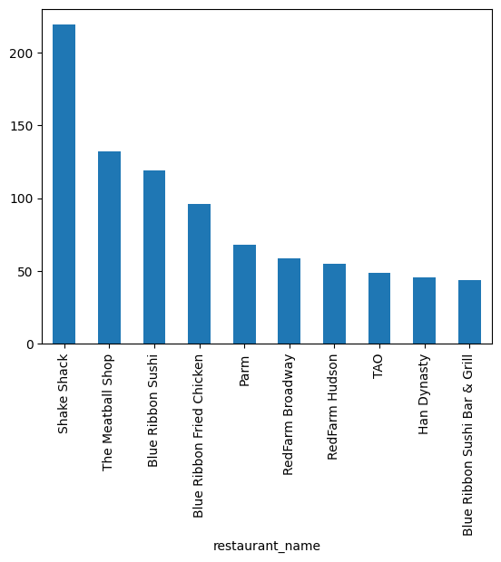

```python
data['restaurant_name'].value_counts()[:10].plot(kind="bar")
plt.show()
```

**Observations**

- 178 different restaurants data is available
- Top 5 restaurants have served almost 1/3rd of total orders.
- Shake Shack has served the most amount of orders.

**Cuisine Type**

```python
data['cuisine_type'].value_counts()[:5].sum() / data.shape[0] * 100
```

```
np.float64(86.61749209694415)
```

```python
len(data['cuisine_type'].unique().tolist())
```

```
14
```

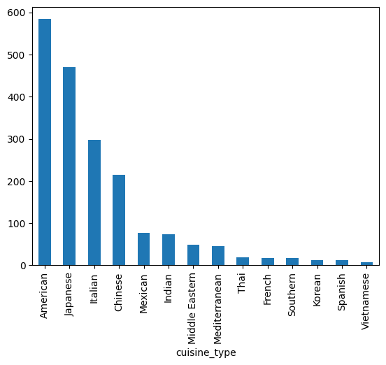

```python
data['cuisine_type'].value_counts().plot(kind="bar")
plt.show()
```

**Observations**

- 14 different cuisine type data is available
- Top 5 cuisines account for 86% of the total orders
- American and Japanese cuisines are the most popular

**Day of Week**

```python
data['day_of_the_week'].value_counts()[:1].sum() / data.shape[0] * 100
```

```
np.float64(71.18018967334035)
```

```python
len(data['day_of_the_week'].unique().tolist())
```

```
2
```

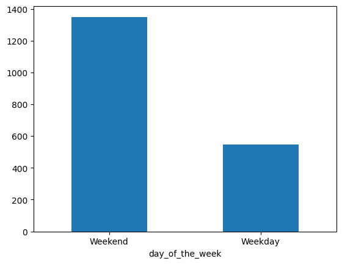

```python
data['day_of_the_week'].value_counts().plot(kind="bar", rot=0)
plt.show()
```

**Observations**

- 71% of orders were placed over weekends

**Rating**

```python
data['rating'].value_counts().loc[:1].sum() / data.shape[0] * 100
```

```
np.float64(61.22233930453108)
```

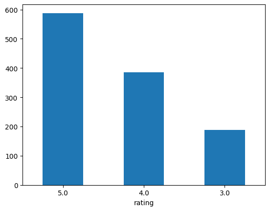

```python
data['rating'].value_counts().plot(kind="bar", rot=0)
plt.show()
```

### **Question 7**: Which are the top 5 restaurants in terms of the number of orders received? [1 mark]

```python
top_restaurants = data['restaurant_name'].value_counts()[:5].keys().tolist()
print(f"Top 5 restaurants are:\n{'\n'.join(top_restaurants)}")
```

```
Top 5 restaurants are:
Shake Shack
The Meatball Shop
Blue Ribbon Sushi
Blue Ribbon Fried Chicken
Parm
```

### **Question 8**: Which is the most popular cuisine on weekends? [1 mark]

```python
# Write the code here
most_pop_on_weekend = data[data['day_of_the_week'] == 'Weekend']['cuisine_type'].value_counts()[:1]
print(f"Most popular cuisine on weekend is:\n{most_pop_on_weekend.index[0]}")
```

```
Most popular cuisine on weekend is:
American
```

### **Question 9**: What percentage of the orders cost more than 20 dollars? [2 marks]

```python
# Write the code here
percentage = data[data['cost_of_the_order'] > 20.].shape[0] / data.shape[0] * 100
```

```python
print(f"Percentage of orders costing more than 20 dollars are:\n{percentage:.2f}%")
```

```
Percentage of orders costing more than 20 dollars are:
29.24%
```

### **Question 10**: What is the mean order delivery time? [1 mark]

```python
# Write the code here
mean_delivery_time = data['delivery_time'].mean().item()
print(f"Mean order delivery time is:\n{mean_delivery_time:.2f} minutes")
```

```
Mean order delivery time is:
24.16 minutes
```

### **Question 11:** The company has decided to give 20% discount vouchers to the top 3 most frequent customers. Find the IDs of these customers and the number of orders they placed. [1 mark]

```python
# Write the code here
top_3_freq_customers = data_copy['customer_id'].value_counts()[:3]
```

```python
print(f"Top 3 frequent customers:\n")
print(pd.DataFrame(top_3_freq_customers))
```

```
Top 3 frequent customers:

             count
customer_id
52832           13
47440           10
83287            9
```

### **Question 12**: Perform a multivariate analysis to explore relationships between the important variables in the dataset. (It is a good idea to explore relations between numerical variables as well as relations between numerical and categorical variables) [10 marks]

**Correlation heatmap**

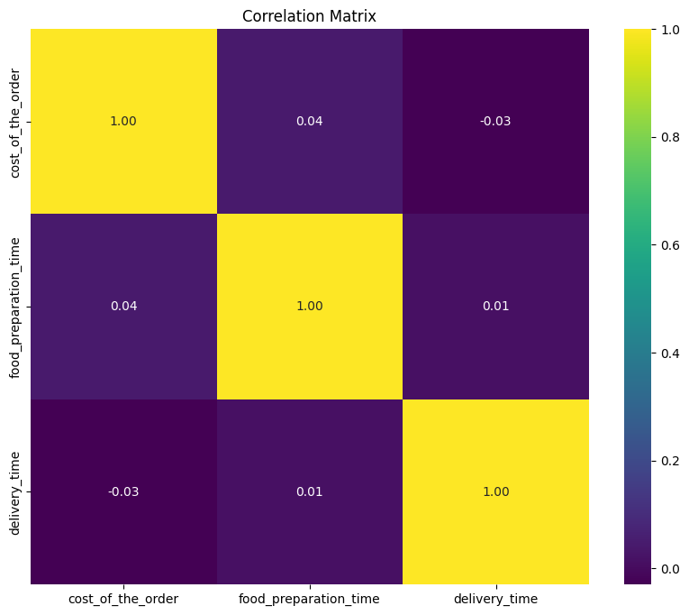

```python
numeric_columns = data_num.columns.tolist()

plt.figure(figsize=(10, 8))
sns.heatmap(data[numeric_columns].corr(), annot=True, cmap="viridis", fmt=".2f")
plt.title("Correlation Matrix")
plt.show()
```

**Observations**

- Cost of the order is not related to food preparation time or delivery time

**Understanding numerical columns**

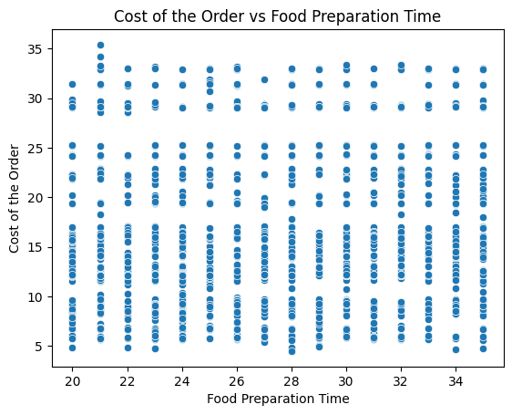

```python
sns.scatterplot(y='cost_of_the_order', x='food_preparation_time', data=data)
plt.title("Cost of the Order vs Food Preparation Time")
plt.ylabel("Cost of the Order")
plt.xlabel("Food Preparation Time")
plt.show()
```

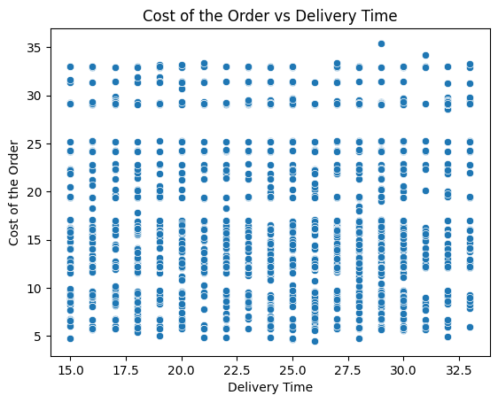

```python
sns.scatterplot(y='cost_of_the_order', x='delivery_time', data=data)
plt.title("Cost of the Order vs Delivery Time")
plt.ylabel("Cost of the Order")
plt.xlabel("Delivery Time")
plt.show()
```

**Understanding Numerical and Categorical columns together**

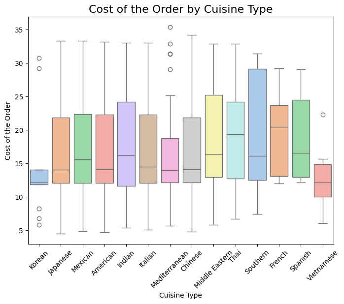

```python
plt.figure(figsize=(8, 6))
sns.boxplot(x='cuisine_type', y='cost_of_the_order', data=data, palette="pastel")
plt.title("Cost of the Order by Cuisine Type", fontsize=16)
plt.xticks(rotation=45)
plt.ylabel("Cost of the Order")
plt.xlabel("Cuisine Type")
plt.show()
```

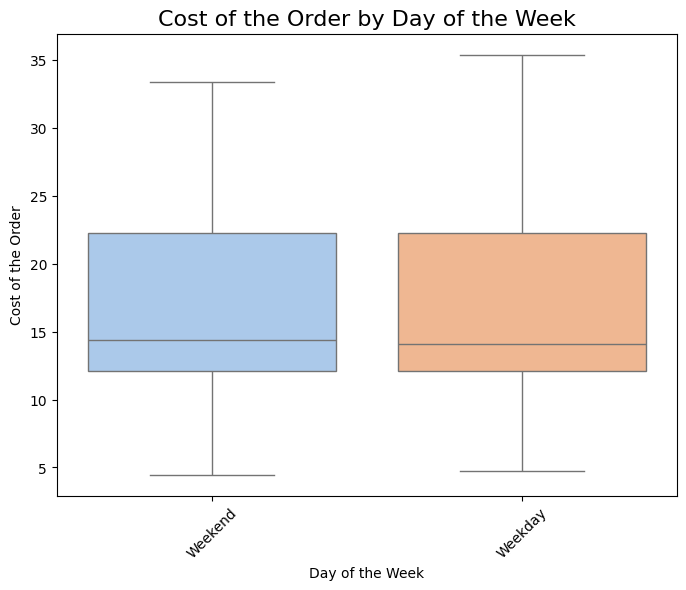

```python
plt.figure(figsize=(8, 6))
sns.boxplot(x='day_of_the_week', y='cost_of_the_order', data=data, palette="pastel")
plt.title("Cost of the Order by Day of the Week", fontsize=16)
plt.xticks(rotation=45)
plt.ylabel("Cost of the Order")
plt.xlabel("Day of the Week")
plt.show()
```

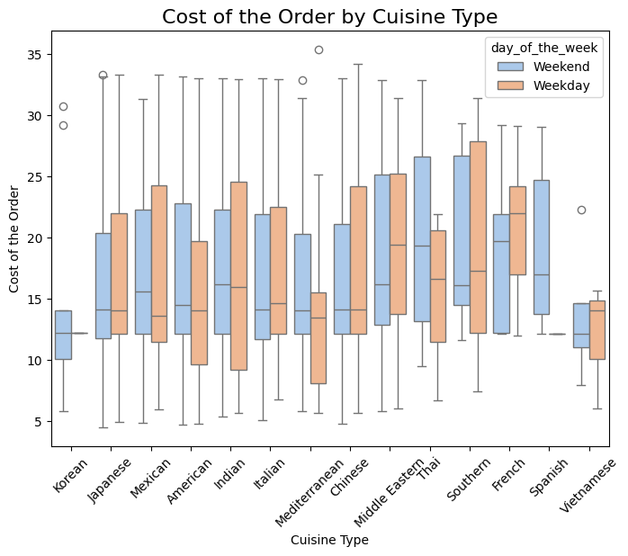

```python
plt.figure(figsize=(8, 6))
sns.boxplot(x='cuisine_type', y='cost_of_the_order', data=data, palette="pastel", hue='day_of_the_week')
plt.title("Cost of the Order by Cuisine Type", fontsize=16)
plt.xticks(rotation=45)
plt.ylabel("Cost of the Order")
plt.xlabel("Cuisine Type")
plt.show()
```

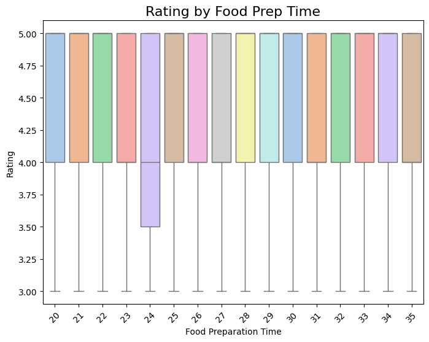

```python
plt.figure(figsize=(8, 6))
sns.boxplot(x='food_preparation_time', y='rating', data=data, palette="pastel")
plt.title("Rating by Food Prep Time", fontsize=16)
plt.xticks(rotation=45)
plt.ylabel("Rating")
plt.xlabel("Food Preparation Time")
plt.show()
```